# 모듈 설치, 임포트

```python
#!pip install matplotlib
#!pip install workalendar
#!pip install xgboost
#!pip install lightgbm
#!pip install catboost
#!pip install pycaret
```

```python
import sys
import numpy as np
import sklearn
import os
import pandas as pd
%matplotlib inline
import matplotlib as mpl
import matplotlib.pyplot as plt
import gc
from workalendar.asia import SouthKorea # 휴일조회모듈
from sklearn.metrics import mean_squared_error
from sklearn.model_selection import GridSearchCV
```

# 데이터 가져오기

```python
from google.colab import drive
drive.mount('/content/drive')
```

```python
def csv_to_parquet(csv_path, save_name):
    df = pd.read_csv(csv_path)
    df.to_parquet(f'./{save_name}.parquet')
    del df
    gc.collect()
    print(save_name, 'Done.')
```

```python
csv_to_parquet('/content/drive/MyDrive/train.csv','train')
csv_to_parquet('/content/drive/MyDrive/test.csv','test')
```

```
train Done.
test Done.
```

```python
# jupyter
#train = pd.read_csv(r"C:\ML\open\train.csv")
#test = pd.read_csv(r"C:\ML\open\test.csv")
#weather = pd.read_csv(r"C:\ML\jejuweatherda.csv", encoding = 'euc_kr') # 2021-09-01 부터 2022-08-31 까지의 제주도 기온 데이터

# COLAB
train = pd.read_parquet("/content/train.parquet")
test = pd.read_parquet("/content/test.parquet")
weather = pd.read_csv(r"/content/drive/MyDrive/jejuweatherda.csv", encoding = 'euc_kr') # 2021-09-01 부터 2022-08-31 까지의 제주도 기온 데이터
```

# 특성 추가하기

특성을 추가하기위해 train.csv와 test.csv를 합친다

```python
data = pd.concat([train,test],axis = 0)
```

```python
data.head()
```

|  | id | base_date | day_of_week | base_hour | road_in_use | lane_count | road_rating | road_name | multi_linked | connect_code | ... | road_type | start_node_name | start_latitude | start_longitude | start_turn_restricted | end_node_name | end_latitude | end_longitude | end_turn_restricted | target |
| --- | --- | --- | --- | --- | --- | --- | --- | --- | --- | --- | --- | --- | --- | --- | --- | --- | --- | --- | --- | --- | --- |
| 0 | TRAIN_0000000 | 20220623 | 목 | 17 | 0 | 1 | 106 | 지방도1112호선 | 0 | 0 | ... | 3 | 제3교래교 | 33.427747 | 126.662612 | 없음 | 제3교래교 | 33.427749 | 126.662335 | 없음 | 52.0 |
| 1 | TRAIN_0000001 | 20220728 | 목 | 21 | 0 | 2 | 103 | 일반국도11호선 | 0 | 0 | ... | 0 | 광양사거리 | 33.500730 | 126.529107 | 있음 | KAL사거리 | 33.504811 | 126.526240 | 없음 | 30.0 |
| 2 | TRAIN_0000002 | 20211010 | 일 | 7 | 0 | 2 | 103 | 일반국도16호선 | 0 | 0 | ... | 0 | 창고천교 | 33.279145 | 126.368598 | 없음 | 상창육교 | 33.280072 | 126.362147 | 없음 | 61.0 |
| 3 | TRAIN_0000003 | 20220311 | 금 | 13 | 0 | 2 | 107 | 태평로 | 0 | 0 | ... | 0 | 남양리조트 | 33.246081 | 126.567204 | 없음 | 서현주택 | 33.245565 | 126.566228 | 없음 | 20.0 |
| 4 | TRAIN_0000004 | 20211005 | 화 | 8 | 0 | 2 | 103 | 일반국도12호선 | 0 | 0 | ... | 0 | 애월샷시 | 33.462214 | 126.326551 | 없음 | 애월입구 | 33.462677 | 126.330152 | 없음 | 38.0 |

5 rows × 24 columns

필요한 열만 남기고 제거

```python
useless = ['id','connect_code','height_restricted'
           ,'start_node_name','end_node_name',
           'vehicle_restricted','road_name']
data = data.drop(useless,axis = 1)
```

```python
data.head()
```

|  | base_date | day_of_week | base_hour | road_in_use | lane_count | road_rating | multi_linked | maximum_speed_limit | weight_restricted | road_type | start_latitude | start_longitude | start_turn_restricted | end_latitude | end_longitude | end_turn_restricted | target |
| --- | --- | --- | --- | --- | --- | --- | --- | --- | --- | --- | --- | --- | --- | --- | --- | --- | --- |
| 0 | 20220623 | 목 | 17 | 0 | 1 | 106 | 0 | 60.0 | 32400.0 | 3 | 33.427747 | 126.662612 | 없음 | 33.427749 | 126.662335 | 없음 | 52.0 |
| 1 | 20220728 | 목 | 21 | 0 | 2 | 103 | 0 | 60.0 | 0.0 | 0 | 33.500730 | 126.529107 | 있음 | 33.504811 | 126.526240 | 없음 | 30.0 |
| 2 | 20211010 | 일 | 7 | 0 | 2 | 103 | 0 | 80.0 | 0.0 | 0 | 33.279145 | 126.368598 | 없음 | 33.280072 | 126.362147 | 없음 | 61.0 |
| 3 | 20220311 | 금 | 13 | 0 | 2 | 107 | 0 | 50.0 | 0.0 | 0 | 33.246081 | 126.567204 | 없음 | 33.245565 | 126.566228 | 없음 | 20.0 |
| 4 | 20211005 | 화 | 8 | 0 | 2 | 103 | 0 | 80.0 | 0.0 | 0 | 33.462214 | 126.326551 | 없음 | 33.462677 | 126.330152 | 없음 | 38.0 |

# 특성추가1

기온 데이터로 계절 구분하기기

```python
base_date_1 = weather['일시'].str[0:4] +weather['일시'].str[5:7]+weather['일시'].str[8:10]
weather['일시'] = pd.to_numeric(base_date_1)
weather = weather.fillna(0)
```

```python
weather.head()
```

|  | 지점 | 지점명 | 일시 | 평균기온(°C) | 일강수량(mm) |
| --- | --- | --- | --- | --- | --- |
| 0 | 184 | 제주 | 20210901 | 28.4 | 14.5 |
| 1 | 184 | 제주 | 20210902 | 25.0 | 37.8 |
| 2 | 184 | 제주 | 20210903 | 24.2 | 21.8 |
| 3 | 184 | 제주 | 20210904 | 25.3 | 0.0 |
| 4 | 184 | 제주 | 20210905 | 24.5 | 7.6 |

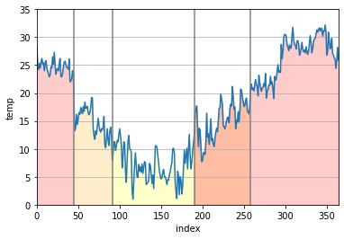

```python
plt.plot(weather.index,weather['평균기온(°C)'])
plt.xlabel('index')
plt.ylabel('temp')
plt.xlim([0,364])
plt.ylim([0,35])
plt.grid(axis = 'y')

plt.plot([45,45], [-5, 35] ,color = 'gray')
plt.fill_between(weather.index[:45],weather['평균기온(°C)'][:45], alpha =0.2, color = 'red')

plt.plot([91,91], [-5, 35],color = 'gray')
plt.fill_between(weather.index[46:91],weather['평균기온(°C)'][46:91], alpha =0.2, color = 'orange')

plt.plot([190,190], [-5, 35],color = 'gray')
plt.fill_between(weather.index[91:190],weather['평균기온(°C)'][91:190], alpha =0.2, color = 'yellow')

plt.plot([258,258], [-5, 35],color = 'gray')
plt.fill_between(weather.index[190:258],weather['평균기온(°C)'][190:258], alpha =0.2, color = 'orange')

plt.fill_between(weather.index[190:],weather['평균기온(°C)'][190:], alpha =0.2, color = 'red')
```

계절별 평균기온 확인해보기

```python
def seasons(x):
    if x < 20211015:
        return 'summer'
    elif x < 20211201:
        return 'autumn'
    elif x < 20220228:
        return 'winter'
    elif x < 20220530:
        return 'spring'
    else:
        return 'summer'
```

```python
weather['season'] = weather['일시'].apply(seasons)
```

```python
weather.groupby('season').mean()['평균기온(°C)']
```

```
season
autumn    15.004255
spring    15.245055
summer    26.286957
winter     6.921348
Name: 평균기온(°C), dtype: float64
```

# 특성추가2

시간대별 속도를 개수가 적은 카테고리로 구분

```python
data_99 = train[['base_hour','target']]
data_98 = data_99.groupby('base_hour').mean()
data_97 = data_99.groupby('base_hour').median()
```

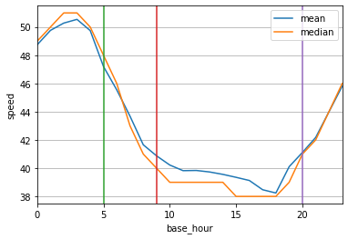

```python
plt.plot(data_98,label='mean')
plt.plot(data_97,label='median')
plt.legend()
plt.xlabel('base_hour')
plt.ylabel('speed')
plt.xlim([0,23])
plt.ylim([37.5,51.5])
plt.grid(axis = 'y')

plt.plot([5,5], [-5, 60])
plt.plot([9,9], [-5, 60])
plt.plot([20,20], [-5, 60])

#0,1,2,3,4
#5,6,7,8
#9,10,11,12,13,14,15,16,17,18,19
#20,21,22,23
```

- 0~4 = 야간
- 5~8 = 아침
- 9~19 = 낮
- 20~23 = 저녁

  으로 구분

```python
def hour(x):
    if x <= 4:
         return 'night'
    elif x <= 8:
        return 'morning'
    elif x <= 19:
        return 'daytime'
    elif x <= 23:
        return 'evening'
    else:
        return 'night'
```

시간 카테고리별 속도 확인, 밤의 평균속도가 높은걸 볼 수 있음

```python
data_99 = data[['base_hour','target']]
data_99['time'] = data_99['base_hour'].apply(hour)
data_99.groupby('time').mean()['target']
```

```
time
daytime    39.576183
evening    43.202651
morning    44.436622
night      49.822387
Name: target, dtype: float64
```

# 특성추가3

```python
# 2021~2022 의 공휴일 리스트
from workalendar.asia import SouthKorea
import pandas as pd
cal = SouthKorea()
a = cal.holidays(2021)
b = cal.holidays(2022)
c = pd.DataFrame(a+b)
c .head(3)
```

|  | 0 | 1 |
| --- | --- | --- |
| 0 | 2021-01-01 | New year |
| 1 | 2021-02-11 | Korean New Year's Day |
| 2 | 2021-02-12 | Korean New Year's Day |

```python
c[0] = c[0].astype(str)
holyday_list = c[0].str[0:4] +c[0].str[5:7]+c[0].str[8:10]
holy_num = holyday_list.astype('int64') #공휴일 날짜를 숫자형 리스트로 변환
```

```python
holy_num
```

```
0     20210101
1     20210211
2     20210212
3     20210213
4     20210301
5     20210505
6     20210519
7     20210606
8     20210815
9     20210920
10    20210921
11    20210922
12    20211003
13    20211009
14    20211225
```

[output cut: 16 more lines]

```python
# 주말 구분 켤럼 추가하기
data['holiday'] = '평일'
data.loc[data['base_date'].isin(holy_num),'holiday']='주말'
```

```python
def date(x):
    if x =='토'or x=='일':
        return '주말'
    else:
        return '평일'
```

```python
data['holiday'] = data['day_of_week'].apply(date)
```

```python
data['holiday'].value_counts()
```

```
평일    3574661
주말    1417797
Name: holiday, dtype: int64
```

```python
data
```

|  | base_date | day_of_week | base_hour | road_in_use | lane_count | road_rating | multi_linked | maximum_speed_limit | weight_restricted | road_type | start_latitude | start_longitude | start_turn_restricted | end_latitude | end_longitude | end_turn_restricted | target | holiday |
| --- | --- | --- | --- | --- | --- | --- | --- | --- | --- | --- | --- | --- | --- | --- | --- | --- | --- | --- |
| 0 | 20220623 | 목 | 17 | 0 | 1 | 106 | 0 | 60.0 | 32400.0 | 3 | 33.427747 | 126.662612 | 없음 | 33.427749 | 126.662335 | 없음 | 52.0 | 평일 |
| 1 | 20220728 | 목 | 21 | 0 | 2 | 103 | 0 | 60.0 | 0.0 | 0 | 33.500730 | 126.529107 | 있음 | 33.504811 | 126.526240 | 없음 | 30.0 | 평일 |
| 2 | 20211010 | 일 | 7 | 0 | 2 | 103 | 0 | 80.0 | 0.0 | 0 | 33.279145 | 126.368598 | 없음 | 33.280072 | 126.362147 | 없음 | 61.0 | 주말 |
| 3 | 20220311 | 금 | 13 | 0 | 2 | 107 | 0 | 50.0 | 0.0 | 0 | 33.246081 | 126.567204 | 없음 | 33.245565 | 126.566228 | 없음 | 20.0 | 평일 |
| 4 | 20211005 | 화 | 8 | 0 | 2 | 103 | 0 | 80.0 | 0.0 | 0 | 33.462214 | 126.326551 | 없음 | 33.462677 | 126.330152 | 없음 | 38.0 | 평일 |
| ... | ... | ... | ... | ... | ... | ... | ... | ... | ... | ... | ... | ... | ... | ... | ... | ... | ... | ... |
| 291236 | 20220827 | 토 | 5 | 0 | 1 | 103 | 0 | 80.0 | 0.0 | 0 | 33.472819 | 126.463030 | 없음 | 33.470483 | 126.460846 | 없음 | NaN | 주말 |
| 291237 | 20220819 | 금 | 20 | 0 | 2 | 103 | 0 | 60.0 | 0.0 | 0 | 33.305359 | 126.598914 | 없음 | 33.300796 | 126.600332 | 없음 | NaN | 평일 |
| 291238 | 20220805 | 금 | 11 | 0 | 1 | 107 | 0 | 30.0 | 0.0 | 0 | 33.493624 | 126.496769 | 있음 | 33.497500 | 126.496946 | 있음 | NaN | 평일 |
| 291239 | 20220812 | 금 | 7 | 0 | 2 | 107 | 0 | 60.0 | 0.0 | 0 | 33.254782 | 126.507014 | 없음 | 33.255659 | 126.507333 | 없음 | NaN | 평일 |
| 291240 | 20220812 | 금 | 10 | 0 | 3 | 106 | 0 | 70.0 | 0.0 | 0 | 33.246996 | 126.524358 | 없음 | 33.247053 | 126.523503 | 없음 | NaN | 평일 |

4992458 rows × 18 columns

# 특성을 추가해주는 파이프라인

```python
def seasons(x):
    if x < 20211015:
        return 'summer'
    elif x < 20211201:
        return 'autumn'
    elif x < 20220228:
        return 'winter'
    elif x < 20220530:
        return 'spring'
    else:
        return 'summer'

def hour(x):
    if x <= 4:
         return 'night'
    elif x <= 8:
        return 'morning'
    elif x <= 19:
        return 'daytime'
    elif x <= 23:
        return 'evening'
    else:
        return 'night'


from sklearn.base import BaseEstimator, TransformerMixin
class Transformer(BaseEstimator,TransformerMixin):

    def fit(self, X,y=None):
        return self

    def transform(self, X, y=None):
        X['time'] = X['base_hour'].apply(hour)
        X['season'] = X['base_date'].apply(seasons)
        return X

transformer = Transformer()
data_feature_added = transformer.fit_transform(data)
```

```python
data_feature_added
```

|  | base_date | day_of_week | base_hour | road_in_use | lane_count | road_rating | multi_linked | maximum_speed_limit | weight_restricted | road_type | start_latitude | start_longitude | start_turn_restricted | end_latitude | end_longitude | end_turn_restricted | target | holiday | time | season |
| --- | --- | --- | --- | --- | --- | --- | --- | --- | --- | --- | --- | --- | --- | --- | --- | --- | --- | --- | --- | --- |
| 0 | 20220623 | 목 | 17 | 0 | 1 | 106 | 0 | 60.0 | 32400.0 | 3 | 33.427747 | 126.662612 | 없음 | 33.427749 | 126.662335 | 없음 | 52.0 | 평일 | daytime | summer |
| 1 | 20220728 | 목 | 21 | 0 | 2 | 103 | 0 | 60.0 | 0.0 | 0 | 33.500730 | 126.529107 | 있음 | 33.504811 | 126.526240 | 없음 | 30.0 | 평일 | evening | summer |
| 2 | 20211010 | 일 | 7 | 0 | 2 | 103 | 0 | 80.0 | 0.0 | 0 | 33.279145 | 126.368598 | 없음 | 33.280072 | 126.362147 | 없음 | 61.0 | 주말 | morning | summer |
| 3 | 20220311 | 금 | 13 | 0 | 2 | 107 | 0 | 50.0 | 0.0 | 0 | 33.246081 | 126.567204 | 없음 | 33.245565 | 126.566228 | 없음 | 20.0 | 평일 | daytime | spring |
| 4 | 20211005 | 화 | 8 | 0 | 2 | 103 | 0 | 80.0 | 0.0 | 0 | 33.462214 | 126.326551 | 없음 | 33.462677 | 126.330152 | 없음 | 38.0 | 평일 | morning | summer |
| ... | ... | ... | ... | ... | ... | ... | ... | ... | ... | ... | ... | ... | ... | ... | ... | ... | ... | ... | ... | ... |
| 291236 | 20220827 | 토 | 5 | 0 | 1 | 103 | 0 | 80.0 | 0.0 | 0 | 33.472819 | 126.463030 | 없음 | 33.470483 | 126.460846 | 없음 | NaN | 주말 | morning | summer |
| 291237 | 20220819 | 금 | 20 | 0 | 2 | 103 | 0 | 60.0 | 0.0 | 0 | 33.305359 | 126.598914 | 없음 | 33.300796 | 126.600332 | 없음 | NaN | 평일 | evening | summer |
| 291238 | 20220805 | 금 | 11 | 0 | 1 | 107 | 0 | 30.0 | 0.0 | 0 | 33.493624 | 126.496769 | 있음 | 33.497500 | 126.496946 | 있음 | NaN | 평일 | daytime | summer |
| 291239 | 20220812 | 금 | 7 | 0 | 2 | 107 | 0 | 60.0 | 0.0 | 0 | 33.254782 | 126.507014 | 없음 | 33.255659 | 126.507333 | 없음 | NaN | 평일 | morning | summer |
| 291240 | 20220812 | 금 | 10 | 0 | 3 | 106 | 0 | 70.0 | 0.0 | 0 | 33.246996 | 126.524358 | 없음 | 33.247053 | 126.523503 | 없음 | NaN | 평일 | daytime | summer |

4992458 rows × 20 columns

날씨, 요일 삭제

```python
data = data_feature_added.drop(['base_date','day_of_week'],axis = 1)
```

합쳤던 train.csv,test.csv 나누기

```python
len(train)
```

```
4701217
```

```python
train_feature_added = data.iloc[:4701217]
test_feature_added = data.iloc[4701217:]
test_feature_added = test_feature_added.drop(['target'], axis = 1)
```

```python
len(train_feature_added), len(test_feature_added)
```

```
(4701217, 291241)
```

```python
train_feature_added.head()
```

|  | base_hour | road_in_use | lane_count | road_rating | multi_linked | maximum_speed_limit | weight_restricted | road_type | start_latitude | start_longitude | start_turn_restricted | end_latitude | end_longitude | end_turn_restricted | target | holiday | time | season |
| --- | --- | --- | --- | --- | --- | --- | --- | --- | --- | --- | --- | --- | --- | --- | --- | --- | --- | --- |
| 0 | 17 | 0 | 1 | 106 | 0 | 60.0 | 32400.0 | 3 | 33.427747 | 126.662612 | 없음 | 33.427749 | 126.662335 | 없음 | 52.0 | 평일 | daytime | summer |
| 1 | 21 | 0 | 2 | 103 | 0 | 60.0 | 0.0 | 0 | 33.500730 | 126.529107 | 있음 | 33.504811 | 126.526240 | 없음 | 30.0 | 평일 | evening | summer |
| 2 | 7 | 0 | 2 | 103 | 0 | 80.0 | 0.0 | 0 | 33.279145 | 126.368598 | 없음 | 33.280072 | 126.362147 | 없음 | 61.0 | 주말 | morning | summer |
| 3 | 13 | 0 | 2 | 107 | 0 | 50.0 | 0.0 | 0 | 33.246081 | 126.567204 | 없음 | 33.245565 | 126.566228 | 없음 | 20.0 | 평일 | daytime | spring |
| 4 | 8 | 0 | 2 | 103 | 0 | 80.0 | 0.0 | 0 | 33.462214 | 126.326551 | 없음 | 33.462677 | 126.330152 | 없음 | 38.0 | 평일 | morning | summer |

# train_set, test_set 나누기

```python
from sklearn.model_selection import train_test_split
train_set, test_set = train_test_split(train_feature_added, test_size=0.2, random_state=42)
```

```python
#X, y 로 나누기
X_train = train_set.drop('target', axis = 1)
y_train = train_set['target']

X_test = test_set.drop('target', axis = 1)
y_test = test_set['target']
```

```python
X_train.head()
```

|  | base_hour | road_in_use | lane_count | road_rating | multi_linked | maximum_speed_limit | weight_restricted | road_type | start_latitude | start_longitude | start_turn_restricted | end_latitude | end_longitude | end_turn_restricted | holiday | time | season |
| --- | --- | --- | --- | --- | --- | --- | --- | --- | --- | --- | --- | --- | --- | --- | --- | --- | --- |
| 1425306 | 5 | 0 | 1 | 106 | 0 | 60.0 | 0.0 | 0 | 33.452688 | 126.709277 | 없음 | 33.438329 | 126.732032 | 없음 | 평일 | morning | spring |
| 981507 | 13 | 0 | 1 | 103 | 0 | 60.0 | 0.0 | 0 | 33.255663 | 126.434978 | 없음 | 33.263239 | 126.443826 | 없음 | 주말 | daytime | summer |
| 4006446 | 14 | 0 | 2 | 103 | 0 | 60.0 | 32400.0 | 3 | 33.265431 | 126.565134 | 없음 | 33.265365 | 126.564924 | 없음 | 평일 | daytime | autumn |
| 2919084 | 13 | 0 | 1 | 107 | 0 | 50.0 | 0.0 | 0 | 33.389755 | 126.798301 | 없음 | 33.383600 | 126.793649 | 없음 | 주말 | daytime | winter |
| 4639662 | 14 | 0 | 3 | 107 | 0 | 60.0 | 0.0 | 0 | 33.256204 | 126.560555 | 없음 | 33.253200 | 126.561049 | 없음 | 주말 | daytime | spring |

# 표준화, 범주형 변수 구분하기

파이프라인

```python
list_cat = ['road_in_use','road_rating','multi_linked','weight_restricted','road_type','start_turn_restricted','end_turn_restricted','holiday','time','season']
list_num = ['base_hour', 'lane_count','maximum_speed_limit','start_latitude','start_longitude','end_latitude','end_longitude']
```

```python
from sklearn.pipeline import Pipeline
from sklearn.preprocessing import StandardScaler
from sklearn.preprocessing import OneHotEncoder
from sklearn.compose import ColumnTransformer

num_pipeline = Pipeline([('std_scaler', StandardScaler())])

full_pipeline = ColumnTransformer([
        ("num", num_pipeline, list_num),
        ("cat", OneHotEncoder(), list_cat),
    ])

X_train_prepared = full_pipeline.fit_transform(X_train)
```

```python
X_train_prepared
```

```
array([[-1.03060374, -1.21638351, -0.10339648, ...,  1.        ,
         0.        ,  0.        ],
       [ 0.15940245, -1.21638351, -0.10339648, ...,  0.        ,
         1.        ,  0.        ],
       [ 0.30815322,  0.23761276, -0.10339648, ...,  0.        ,
         0.        ,  0.        ],
       ...,
       [-1.03060374,  0.23761276, -0.10339648, ...,  0.        ,
         0.        ,  1.        ],
       [ 0.30815322,  1.69160903,  0.72097957, ...,  0.        ,
         1.        ,  0.        ],
       [ 0.15940245,  0.23761276,  0.72097957, ...,  0.        ,
         1.        ,  0.        ]])
```

데이터프레임으로 바꿔보기

```python
colname =list_num+full_pipeline.named_transformers_['cat'].get_feature_names().tolist()

X_train_df = pd.DataFrame(
    X_train_prepared,
    columns = colname,
    index = X_train.index)
```

```python
X_train_df.head()
```

|  | base_hour | lane_count | maximum_speed_limit | start_latitude | start_longitude | end_latitude | end_longitude | x0_0 | x0_1 | x1_103 | ... | x7_주말 | x7_평일 | x8_daytime | x8_evening | x8_morning | x8_night | x9_autumn | x9_spring | x9_summer | x9_winter |
| --- | --- | --- | --- | --- | --- | --- | --- | --- | --- | --- | --- | --- | --- | --- | --- | --- | --- | --- | --- | --- | --- |
| 1425306 | -1.030604 | -1.216384 | -0.103396 | 0.675718 | 1.199843 | 0.533846 | 1.345469 | 1.0 | 0.0 | 0.0 | ... | 0.0 | 1.0 | 0.0 | 0.0 | 1.0 | 0.0 | 0.0 | 1.0 | 0.0 | 0.0 |
| 981507 | 0.159402 | -1.216384 | -0.103396 | -1.271160 | -0.554644 | -1.196406 | -0.498152 | 1.0 | 0.0 | 1.0 | ... | 1.0 | 0.0 | 1.0 | 0.0 | 0.0 | 0.0 | 0.0 | 0.0 | 1.0 | 0.0 |
| 4006446 | 0.308153 | 0.237613 | -0.103396 | -1.174643 | 0.277867 | -1.175394 | 0.276495 | 1.0 | 0.0 | 1.0 | ... | 0.0 | 1.0 | 1.0 | 0.0 | 0.0 | 0.0 | 1.0 | 0.0 | 0.0 | 0.0 |
| 2919084 | 0.159402 | -1.216384 | -0.927773 | 0.053849 | 1.769265 | -0.006982 | 1.739631 | 1.0 | 0.0 | 0.0 | ... | 1.0 | 0.0 | 1.0 | 0.0 | 0.0 | 0.0 | 0.0 | 0.0 | 0.0 | 1.0 |
| 4639662 | 0.308153 | 1.691609 | -0.103396 | -1.265817 | 0.248579 | -1.295606 | 0.251708 | 1.0 | 0.0 | 0.0 | ... | 1.0 | 0.0 | 1.0 | 0.0 | 0.0 | 0.0 | 0.0 | 1.0 | 0.0 | 0.0 |

5 rows × 34 columns

test_set도 파이프라인 통과시키기

```python
X_test_prepared = full_pipeline.transform(X_test)
```

```python
colname =list_num+full_pipeline.named_transformers_['cat'].get_feature_names().tolist()

X_test_df = pd.DataFrame(
    X_test_prepared,
    columns = colname,
    index = X_test.index)
```

```python
X_test_df.head()
```

|  | base_hour | lane_count | maximum_speed_limit | start_latitude | start_longitude | end_latitude | end_longitude | x0_0 | x0_1 | x1_103 | ... | x7_주말 | x7_평일 | x8_daytime | x8_evening | x8_morning | x8_night | x9_autumn | x9_spring | x9_summer | x9_winter |
| --- | --- | --- | --- | --- | --- | --- | --- | --- | --- | --- | --- | --- | --- | --- | --- | --- | --- | --- | --- | --- | --- |
| 1668774 | -1.476856 | 0.237613 | -0.103396 | 1.096468 | -0.394927 | 1.093177 | -0.384441 | 1.0 | 0.0 | 1.0 | ... | 1.0 | 0.0 | 0.0 | 0.0 | 0.0 | 1.0 | 0.0 | 0.0 | 0.0 | 1.0 |
| 299795 | -0.138099 | 1.691609 | 0.720980 | 1.001985 | 0.527504 | 0.946173 | 0.663906 | 1.0 | 0.0 | 0.0 | ... | 1.0 | 0.0 | 1.0 | 0.0 | 0.0 | 0.0 | 0.0 | 0.0 | 1.0 | 0.0 |
| 2245633 | 0.010652 | -1.216384 | -0.927773 | -1.210948 | -0.697914 | -1.208400 | -0.686646 | 1.0 | 0.0 | 0.0 | ... | 1.0 | 0.0 | 1.0 | 0.0 | 0.0 | 0.0 | 0.0 | 0.0 | 1.0 | 0.0 |
| 434484 | -1.625607 | 0.237613 | -0.103396 | 0.591058 | 2.502576 | 0.499311 | 2.481721 | 1.0 | 0.0 | 1.0 | ... | 1.0 | 0.0 | 0.0 | 0.0 | 0.0 | 1.0 | 0.0 | 0.0 | 1.0 | 0.0 |
| 4562091 | -0.286850 | -1.216384 | -0.103396 | -0.914600 | -0.106701 | -0.914846 | -0.110692 | 1.0 | 0.0 | 0.0 | ... | 1.0 | 0.0 | 1.0 | 0.0 | 0.0 | 0.0 | 0.0 | 0.0 | 1.0 | 0.0 |

5 rows × 34 columns

# 모델 성능 비교시 시간 단축을 위해 샘플 추출

```python
X_train_sample = X_train_df.sample(frac = 0.1, random_state= 2022)
y_train_sample = y_train[X_train_sample.index]
```

```python
X_train_sample
```

|  | base_hour | lane_count | maximum_speed_limit | start_latitude | start_longitude | end_latitude | end_longitude | x0_0 | x0_1 | x1_103 | ... | x7_주말 | x7_평일 | x8_daytime | x8_evening | x8_morning | x8_night | x9_autumn | x9_spring | x9_summer | x9_winter |
| --- | --- | --- | --- | --- | --- | --- | --- | --- | --- | --- | --- | --- | --- | --- | --- | --- | --- | --- | --- | --- | --- |
| 980736 | -0.138099 | 0.237613 | -0.103396 | -1.174643 | 0.277867 | -1.167682 | 0.297172 | 1.0 | 0.0 | 1.0 | ... | 0.0 | 1.0 | 1.0 | 0.0 | 0.0 | 0.0 | 0.0 | 0.0 | 1.0 | 0.0 |
| 1662221 | 1.051907 | 0.237613 | 1.545356 | 0.599706 | -0.565172 | 0.585902 | -0.574976 | 1.0 | 0.0 | 1.0 | ... | 1.0 | 0.0 | 1.0 | 0.0 | 0.0 | 0.0 | 0.0 | 0.0 | 0.0 | 1.0 |
| 3241506 | -1.476856 | 0.237613 | -0.927773 | -0.763606 | 1.820450 | -0.764160 | 1.817405 | 1.0 | 0.0 | 1.0 | ... | 0.0 | 1.0 | 0.0 | 0.0 | 0.0 | 1.0 | 0.0 | 1.0 | 0.0 | 0.0 |
| 464 | 1.498159 | -1.216384 | -0.927773 | 0.636203 | 2.524386 | 0.651312 | 2.552818 | 1.0 | 0.0 | 0.0 | ... | 0.0 | 1.0 | 0.0 | 1.0 | 0.0 | 0.0 | 0.0 | 0.0 | 0.0 | 1.0 |
| 2787752 | -1.625607 | 1.691609 | 0.720980 | 1.257633 | 0.165486 | 1.239431 | 0.137174 | 1.0 | 0.0 | 1.0 | ... | 1.0 | 0.0 | 0.0 | 0.0 | 0.0 | 1.0 | 0.0 | 0.0 | 1.0 | 0.0 |
| ... | ... | ... | ... | ... | ... | ... | ... | ... | ... | ... | ... | ... | ... | ... | ... | ... | ... | ... | ... | ... | ... |
| 502158 | 1.646910 | 1.691609 | 0.720980 | 0.952300 | -0.316456 | 0.928426 | -0.342999 | 1.0 | 0.0 | 1.0 | ... | 1.0 | 0.0 | 0.0 | 1.0 | 0.0 | 0.0 | 1.0 | 0.0 | 0.0 | 0.0 |
| 995475 | 0.605655 | -1.216384 | -0.103396 | -1.211606 | -0.438716 | -1.212055 | -0.441654 | 1.0 | 0.0 | 1.0 | ... | 0.0 | 1.0 | 1.0 | 0.0 | 0.0 | 0.0 | 0.0 | 0.0 | 1.0 | 0.0 |
| 3751110 | 0.605655 | -1.216384 | -2.576525 | -1.309212 | -0.697735 | -1.317325 | -0.700697 | 1.0 | 0.0 | 0.0 | ... | 1.0 | 0.0 | 1.0 | 0.0 | 0.0 | 0.0 | 0.0 | 0.0 | 1.0 | 0.0 |
| 1844550 | 0.010652 | -1.216384 | -2.576525 | -1.365157 | -0.668282 | -1.331902 | -0.681478 | 1.0 | 0.0 | 0.0 | ... | 1.0 | 0.0 | 1.0 | 0.0 | 0.0 | 0.0 | 0.0 | 0.0 | 0.0 | 1.0 |
| 1997509 | -0.733102 | 1.691609 | -0.927773 | 1.285413 | 0.218892 | 1.278757 | 0.209706 | 1.0 | 0.0 | 1.0 | ... | 0.0 | 1.0 | 0.0 | 0.0 | 1.0 | 0.0 | 0.0 | 1.0 | 0.0 | 0.0 |

376097 rows × 34 columns

```python
y_train_sample
```

```
980736     32.0
1662221    69.0
3241506    39.0
464        42.0
2787752    27.0
           ...
502158     49.0
995475     45.0
3751110    30.0
1844550    37.0
1997509    27.0
Name: target, Length: 376097, dtype: float64
```

# 모델 선정하기

X_test에 대한 예측값과 y_test의 RMSE 값을 비교

- LinearRegression

```python
from sklearn.linear_model import LinearRegression

lin_reg = LinearRegression()
lin_reg.fit(X_train_sample,y_train_sample)

lin_pred = lin_reg.predict(X_test_df)
lin_mse = mean_squared_error(y_test,lin_pred)
lin_mse**0.5
```

```
11.948879233487032
```

- DecisionTreeRegressor

```python
from sklearn.tree import DecisionTreeRegressor

tree_reg = DecisionTreeRegressor(random_state=42)
tree_reg.fit(X_train_sample,y_train_sample)

tree_pred = tree_reg.predict(X_test_df)
tree_mse = mean_squared_error(y_test,tree_pred)
tree_mse**0.5
```

```
5.761558200380028
```

- RandomForest (Default)

```python
from sklearn.ensemble import RandomForestRegressor

forest_reg = RandomForestRegressor(n_estimators=100, random_state=42)
forest_reg.fit(X_train_sample,y_train_sample)

forest_pred = forest_reg.predict(X_test_df)
forest_mse = mean_squared_error(y_test,forest_pred)
forest_mse**0.5
```

```
5.385962442877231
```

- RandomForest GridSearch
  - n_estimators : [10, 50, 100, 200], max_features : [6, 8]
  - bootstrap: [False], n_estimators: [50, 100], max_features: [6, 8]

```python
param_grid = [
    {'n_estimators': [10, 50, 100, 200], 'max_features': [6, 8]},
    {'bootstrap': [False], 'n_estimators': [50, 100], 'max_features': [6, 8]},
  ]

forest_reg = RandomForestRegressor(random_state=42)

grid_search = GridSearchCV(forest_reg, param_grid, cv=3,
                           scoring='neg_mean_squared_error',
                           return_train_score=True)

grid_search.fit(X_train_sample,y_train_sample)
```

```
GridSearchCV(cv=3, estimator=RandomForestRegressor(random_state=42),
             param_grid=[{'max_features': [6, 8],
                          'n_estimators': [10, 50, 100, 200]},
                         {'bootstrap': [False], 'max_features': [6, 8],
                          'n_estimators': [50, 100]}],
             return_train_score=True, scoring='neg_mean_squared_error')
```

```python
grid_search.best_params_
```

```
{'max_features': 8, 'n_estimators': 200}
```

```python
forest_best_reg = RandomForestRegressor(n_estimators=200,max_features=8, random_state=42)
forest_best_reg.fit(X_train_prepared,y_train)

forest_best_pred = forest_best_reg.predict(X_test_prepared)
forest_best_mse = mean_squared_error(y_test,forest_best_pred)
forest_best_mse**0.5
```

[output not shown]

- XGBRegressor (Default)

```python
import xgboost

xgb_reg = xgboost.XGBRegressor(objective='reg:squarederror',n_estimators=100,random_state = 42)
xgb_reg.fit(X_train_sample,y_train_sample)

xgb_pred = xgb_reg.predict(X_test_df)
xgb_mse = mean_squared_error(y_test,xgb_pred)
xgb_mse**0.5
```

[output not shown]

- XGBRegressor GridSearch
  - max_depth: [10,30,50]
  - min_child_weight : [3,6]
  - n_estimators : [100]
  - learning_rate : [0.1, 0.16, 0.2]

```python
model = xgboost.XGBRegressor()
param_dist = {"max_depth": [10,30,50],
              "min_child_weight" : [3,6],
              "n_estimators": [100],
              "learning_rate": [0.1, 0.16, 0.2],}

grid_search = GridSearchCV(model, param_grid=param_dist, cv = 3,
                                   verbose=10, n_jobs=-1)

grid_search.fit(X_train_sample,y_train_sample)
```

```python
grid_search.best_params_
```

[output not shown]

```python
xgb_best_reg = xgboost.XGBRegressor(objective='reg:squarederror',n_estimators=100, learning_rate=0.2, max_depth=10, min_child_weight=6)
xgb_best_reg.fit(X_train_sample,y_train_sample)

xgb_best_pred = xgb_best_reg.predict(X_test_df)
xgb_best_mse = mean_squared_error(y_test,xgb_best_pred)
xgb_best_mse**0.5
```

[output not shown]

- lightgbm (Default)

```python
X_train_sample_array = np.array(X_train_sample)
X_test_sample = X_test_df.sample(frac = 0.1, random_state=2022)
X_test_sample_array = np.array(X_test_sample)
y_test_sample = y_test[X_test_sample.index]
```

```python
import lightgbm as lgb

params = {}

train_ds = lgb.Dataset(X_train_sample_array, label = y_train_sample)
test_ds = lgb.Dataset(X_test_sample_array, label = y_test_sample)

lgb_reg = lgb.train(params, train_ds, 1000, test_ds, verbose_eval=100, early_stopping_rounds=100)
```

```python
lgb_pred = lgb_reg.predict(X_test_prepared)
lgb_mse = mean_squared_error(y_test,lgb_pred)
lgb_mse**0.5
```

[output not shown]

```python
from sklearn.model_selection import GridSearchCV
```

```python
lgb_grid_model = lgb.LGBMRegressor()

param_dist = {"max_depth": [25, 50],
              "learning_rate" : [0.01, 0.05, 0.1],
              "num_leaves": [600, 900, 1200],
              "n_estimators": [50]
             }
lgb_grid_search = GridSearchCV(lgb_grid_model, n_jobs=-1, param_grid=param_dist, cv = 3, scoring='neg_root_mean_squared_error', verbose=5)
```

```python
lgb_grid_search.fit(X_train_sample,y_train_sample)

lgb_grid_search.best_estimator_
```

```python
params = {'max_depth': 25, 'n_estimators':50, 'num_leaves':1200}

train_ds = lgb.Dataset(X_train_sample_array, label = y_train_sample)
test_ds = lgb.Dataset(X_test_sample_array, label = y_test_sample)

lgb_best_reg = lgb.train(params, train_ds, 1000, test_ds, verbose_eval=100, early_stopping_rounds=100)

lgb_best_pred = lgb_best_reg.predict(X_test_prepared)
lgb_best_mse = mean_squared_error(y_test,lgb_best_pred)
lgb_best_mse**0.5
```

[output not shown]

- catboost (Default)

```python
import catboost as cb
```

```python
cb_reg = cb.CatBoostRegressor()
```

```python
cb_reg.fit(X_train_sample,y_train_sample)
```

```python
cb_pred = cb_reg.predict(X_test_df)
cb_mse = mean_squared_error(y_test,cb_pred)
cb_mse**0.5
```

[output not shown]

- catboost GridSearch

```python
from catboost.core import CatBoostRegressor
cb_2 = CatBoostRegressor()

params = {'depth': [4, 7, 10],
          'learning_rate' : [0.03, 0.1, 0.15],
         'l2_leaf_reg': [1,4,9],
         'iterations': [300]}

cb_grid = GridSearchCV(cb_2, params, cv = 3, scoring='neg_root_mean_squared_error')
cb_grid.fit(X_train_sample,y_train_sample)

cb_grid.best_estimator_
```

```python
cb_grid.best_params_
```

[output not shown]

```python
cb_best_reg = CatBoostRegressor(depth=10, iterations=300, l2_leaf_reg=1, learning_rate=0.15)
cb_best_reg.fit(X_train_sample,y_train_sample)

cb_best_pred = cb_best_reg.predict(X_test_df)
cb_best_mse = mean_squared_error(y_test,cb_best_pred)
cb_best_mse**0.5
```

[output not shown]

# 모델 성능 시각화

```python
model = ['lin','tree','forest','forest_GS','xgb','xgb_GS','lgb','lgb_GS','cb','cb_GS']
score_ = [lin_mse, tree_mse, forest_mse, forest_best_mse, xgb_mse, xgb_best_mse, lgb_mse, lgb_best_mse, cb_mse, cb_best_mse]
```

```python
fna = {'model_' : ['lin','tree','forest','forest_GS','xgb','xgb_GS','lgb','lgb_GS','cb','cb_GS'],
'score_mse' :[142.77706735960416,
 33.195552896366344,
 29.008591436084075,
 23.632663818302866,
 29.525785838108167,
 24.922643904310853,
 25.992413335403306,
 25.016558976238926,
 29.289347495401064,
 28.239800598176032]}
```

```python
score_df = pd.DataFrame(fna)
score_df['score_rmse']=score_df['score_mse']**0.5
score_df
```

[output not shown]

```python
import matplotlib.pyplot as plt

def visualize(pred):
    plt.scatter(y_test,pred,alpha = 0.02)
    plt.xlabel('True Values')
    plt.ylabel('Predictions')
    plt.axis('equal')
    plt.axis('square')
    plt.xlim([-5,110])
    plt.ylim([-5,110])
    plt.plot([-10,120], [-10,120])

visualize(xgb_best_pred)
```

[output not shown]

```python
import matplotlib.pyplot as plt

def visualize(pred):
    plt.scatter(y_test,pred,alpha = 0.005)
    plt.xlabel('True Values')
    plt.ylabel('Predictions')
    plt.axis('equal')
    plt.axis('square')
    plt.xlim([-5,110])
    plt.ylim([-5,110])
    plt.plot([-10,120], [-10,120])

prediction = [lin_pred, tree_pred, forest_pred, forest_best_pred, xgb_pred, xgb_best_pred, lgb_pred, lgb_best_pred, cb_pred, cb_best_pred]
titles = ['lin','tree','forest','forest_GS','xgb','xgb_GS','lgb','lgb_GS','cb','cb_GS']

for i in range(len(prediction)):
    plt.subplot(3,4,i+1)
    visualize(prediction[i])
    plt.title(titles[i])
    plt.tight_layout()


plt.show()
```

[output not shown]

# 예측,제출

```python
test_feature_added.head()
```

```python
# 파이프라인 통과시키기
test_submission = full_pipeline.transform(test_feature_added)
```

```python
test_submission
```

선정한 모델을 전체 데이터로 학습

```python
xgb_reg_sub = xgboost.XGBRegressor(objective='reg:squarederror',n_estimators=100, learning_rate=0.2, max_depth=10, min_child_weight=6)
xgb_reg_sub.fit(X_train_prepared,y_train)
```

```python
from sklearn.metrics import mean_squared_error
xgb_pred = xgb_reg_sub.predict(X_test_df)
xgb_mse = mean_squared_error(y_test,xgb_pred)
xgb_mse**0.5
```

[output not shown]

```python
#선정한 모델로 예측
target_submission = xgb_reg_sub.predict(test_submission)
```

```python
#데이터프레임으로 바꾼 후, id 값과 붙히기
target_submission_df = pd.DataFrame(target_submission, columns=['target'])
submission_file = pd.concat([test['id'], target_submission_df], axis = 1)
```

```python
#CSV로 저장
submission_file.to_csv('submission_file.csv', index = False)
```

```python
#저장 함수
def submi_fn(model,filename):
  x1 = model.predict(test_submission)
  x2 = pd.DataFrame(x1,columns=['target'])
  x3 = pd.concat([test['id'], x2], axis = 1)
  x3.to_csv(f'./{filename}.csv', index = False)
```

```python
submi_fn(lin_reg,'lin_reg')
```

### 최종점수

[figure not shown]